# STA130 Final Project

## Introduction

On November 21, 2018, Riipen, a Vancouver-based education technology company, launched a new feature called “request expiry”.  
This project is going to show how user behaviour have changed after the launch of request expiry from the following perspectives.

## Objectives

### Change in the behaviour of recipients

- Whether the **response rate** (in 14days) changed?
- How the **response time** has changed?

### Change in the behaviour of creators

- How the **number of requests created per day** has changed?
- How the **number of accounts created per month** has changed?

## Data Summary

- mutate()&ifelse(): add the type of users into request.xlsx
- mutate()&as.Date(): change variable types from chr to date
- mutate()&substr(): add the month of each request created at
- filter(): filter out data on 2018-4-12 & 2018-8-30 (extreme)

## Response rate (in 14 Days)

### State hypothesis

**Null hypothesis**: \(H_0: rate\_diff=0\)  
The response rate did not change after the November 21 launch of request expiry.  
**Alternative hypothesis**: \(H_a: rate\_diff\ne0\)  
The response rate has changed after the November 21 launch of request expiry.

### Calculate test statistic:

- Filter out the requests still pending
- Summarise the response rate before and after 2018-11-21
- Calculate the difference.
- Test statistic (rate_diff):

```
## [1] 0.07808326
```

## Response rate (in 14 Days)

### Simulate under the null hypothesis

- Shuffle the variable of the day requested created at
- Calculate the difference between the response rate before and after 2018-11-21
- Repeat 1000 times
- Turn the result into a data frame and plot the data

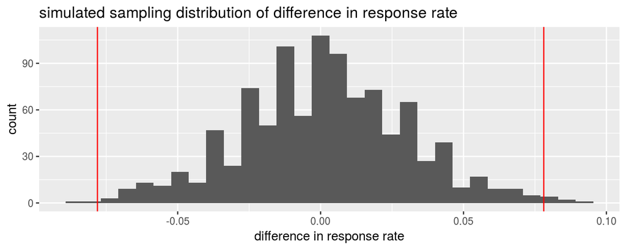

## Response rate (in 14 Days)

### Assess evidence against the null hypothesis

- Compare the test statistic to the simulated sampling distribution
- Calculate the p-value:

```
## [1] 0.009
```

### Conclusion

p-value=0.009<0.01  
We have strong evidence against the null hypothesis

## Response rate (in 14 Days)

### **Different types of recipients**

**professor**: too few observations to draw a conclusion  
**student**:

- test statistic: stu_diff=0.1768805
- p-value=0
- 95% confidence interval

```
##       2.5%      97.5%
## 0.07873107 0.27436534
```

**employer**:

- test statistic: emp_diff=0.01536152
- p-value=0.706>0.1

## Response time

### **hypothesis test & p-value**

- hypothesis- hypothesis  
  **Null hypothesis**:  
  The average response time did not change after the November 21 launch of request expiry. \[H_0: time\_diff=0\] **Alternative hypothesis**:  
  The average response time has changed after the November 21 launch of request expiry. \[H_a: time\_diff\ne0\]
- test statistic: (time_diff)

```
## [1] -13.13395
```

## Response time

### **hypothesis test & p-value**

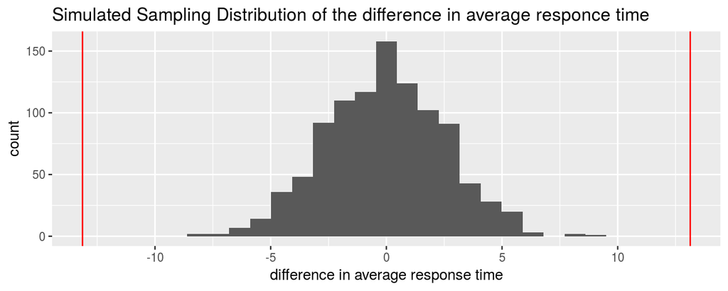

- p-value

```
## [1] 0
```

- conclusion  
  p-value=0  
  We have strong evidence against the null hypothesis.

## Response time

### **bootstrap sampling & confidence interval**

### bootstrap sample

- Draw 1000 bootstrap samples of the same size as the original sample with replacement
- For each bootstrap sample, calculate the statistic
- Summarise the value of statistic for all bootstrap samples

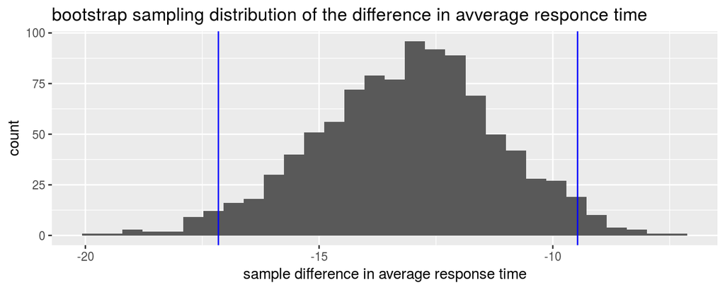

## Response time

### **bootstrap sampling & confidence interval**

### 95% confidence interval

- Calculate the middle 95% interval of values of the bootstrap statistic

```
##       2.5%      97.5%
## -17.154014  -9.470533
```

We are 95% confident that the response time has decreased by between 9.470533 and -17.154014 days after 2018-11-21.

## Number of requests per day

### **clear out outliers**

We plotted a scartter plot for number of requests created each day.  
From the plot, we discovered an outlier at 2019-02-28 and cleared it out.

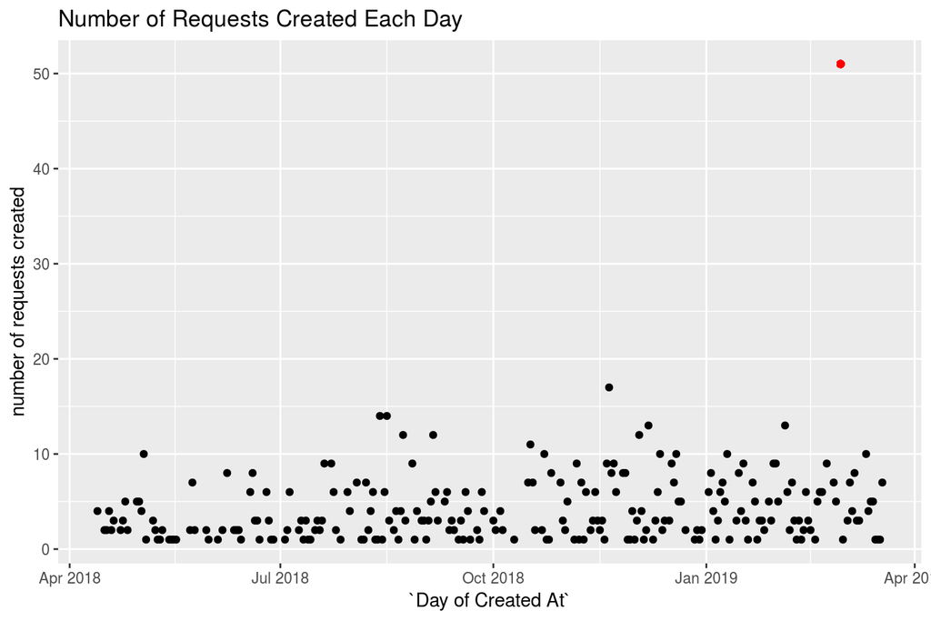

## Number of requests per day

### **hypothesis test & p-value**

- hypothesis  
  **Null hypothesis**:  
  The number of requests created per day did not change after the November 21 launch of request expiry. \[H_0: num\_diff=0\] **Alternative hypothesis**:  
  The number of requests created per day has changed after the November 21 launch of request expiry. \[H_a: num\_diff\ne0\]
- test statistic: (num_diff)

```
## [1] 0.9413082
```

## Number of requests per day

### **hypothesis test & p-value**

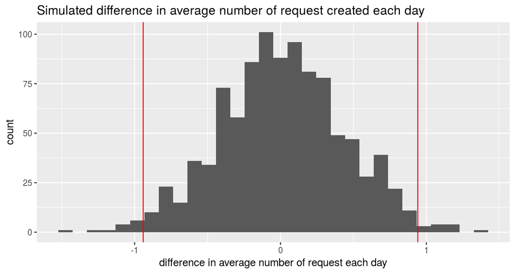

- p-value

```
## [1] 0.024
```

- conclusion  
  p-value=0.024<0.05  
  We have evidence against the null hypothesis.

## Number of requests per day

### **bootstrap sampling & confidence interval**

- bootstrap sampling distribution:

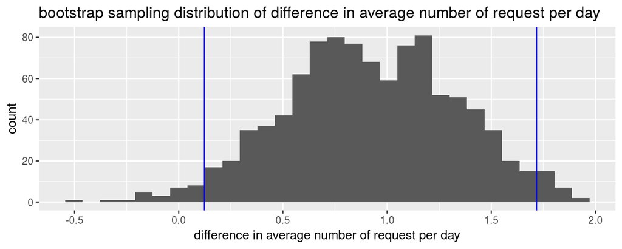

- 95% confidence interval

```
##      2.5%     97.5%
## 0.1232033 1.7172502
```

## Number of new accounts created

### **clean up data**

- summarise the number of accounts craeted each month
- filter out accounts created on ‘2017-02-11’ because it is the start date.
- filter out accounts created in ‘2019-03’ because the month is not complete.

## Number of new accounts created

### **hypothesis test & p-value**

- hypothesis  
  **Null hypothesis**:  
  The number of accounts created each month did not change after the November 21 launch of request expiry. \[H_0: account\_diff=0\] **Alternative hypothesis**:  
  The number of accounts created each month has changed after the November 21 launch of request expiry. \[H_a: account\_diff\ne0\]
- test statistic (account_diff):

```
## [1] 215.3636
```

## Number of new accounts created

### **hypothesis test & p-value**

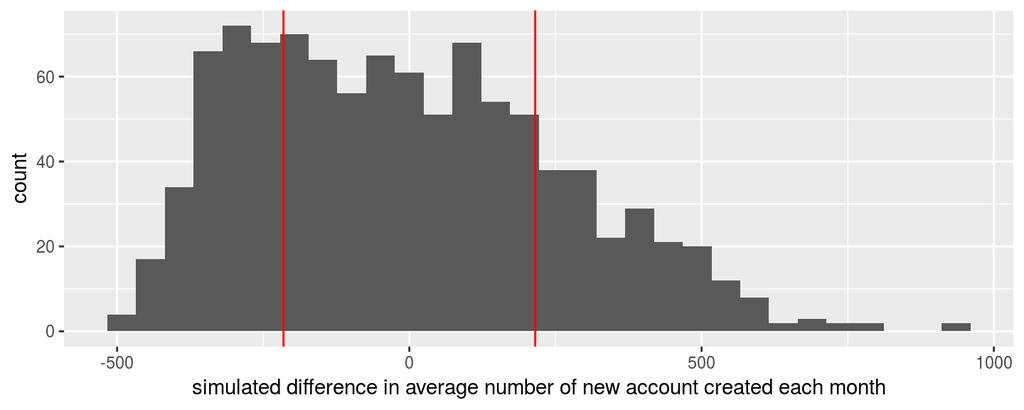

- p-value

```
## [1] 0.476
```

- conclusion p-value=0.476>0.1 We do not have evidence against the null hypothesis.

## Conclusion

### Change in Behaviour of Recipients

**response rate**

- The response rate has changed after the launch of request expiry.
- More specifically:  
  the response rate of employers did not change; the response rate of students has changed, and we are 95% confident that it is increased by between 0.07873107 and 0.27436534.

**response time**

- The average response time has changed after the launch of request expiry.
- We are 95% confident that the average responce time has decreased by between 9.470533 and 17.154014 days.

## Conclusion

### Change in Behaviour of Creators

**number of requests each day**

- The number of requests created each day has changed after the launch of request expiry.
- We are 95% confident that the average number of requests per day has increased by between 0.1232033 and 1.7172502

**number of new accounts each month**

- The number of new accounts created each month did not change after the launch of request expiry.

## Conclusion

### possible explanations

- The launch of request expiry has increased the response rate within 14 days and decreased the responses time, and thus improved user experience.
- Thus,users tend to use Riipen more.
- Since request expiry has launch only 4 months, it has not draw more new users, but is probably going to draw more users.

**limitation**

We did not analyze how many requests are recent after expiry, so probably the number of requests created increase simply because some requests are recent after expiry.